Felicity Zhang https://github.com/felicityxz17/gov51-ps2

# Part 1: The Original Study

## 1.1 Exploring the Experiment

```r
library(tidyverse)
gay <- read_csv("data/raw/gay.csv")
```

### Q1.1

```r
dim(gay)
```

```
## [1] 69592     4
```

```r
table(gay$study)
```

```
##
##     1     2
## 59207 10385
```

```r
table(gay$treatment)
```

```
##
##                                     No Contact
##                                          37735
##              Recycling Script by Gay Canvasser
##                                           6514
##         Recycling Script by Straight Canvasser
##                                           6474
##      Same-Sex Marriage Script by Gay Canvasser
##                                          12452
## Same-Sex Marriage Script by Straight Canvasser
##                                           6417
```

The dataset contains 69,592 total observations, and the variable `study` takes on 2 unique values, `1` and `2`.

There are 5 treatment conditions:

1. No Contact
2. Recycling Script by Gay Canvasser
3. Recycling Script by Straight Canvasser
4. Same-Sex Marriage Script by Gay Canvasser
5. Same-Sex Marriage Script by Straight Canvasser

### Q1.2

```r
gaystudy1wave1 <- gay[(gay$study == 1) & (gay$wave == 1),]
summarize(group_by(gaystudy1wave1, treatment), mean(ssm), length(ssm))
```

```
## # A tibble: 5 × 3
##   treatment                                      `mean(ssm)` `length(ssm)`
##   <chr>                                                <dbl>         <int>
## 1 No Contact                                            3.04          5238
## 2 Recycling Script by Gay Canvasser                     3.13          1046
## 3 Recycling Script by Straight Canvasser                3.01          1039
## 4 Same-Sex Marriage Script by Gay Canvasser             3.03          1151
## 5 Same-Sex Marriage Script by Straight Canvasser        3.10          1033
```

The Recycling Script by Gay Canvasser treatment shows the highest average support, with a mean `ssm` of 3.130975.

### Q1.3

```r
summarize(group_by(gaystudy1wave1, treatment), sd(ssm))
```

```
## # A tibble: 5 × 2
##   treatment                                      `sd(ssm)`
##   <chr>                                              <dbl>
## 1 No Contact                                          1.68
## 2 Recycling Script by Gay Canvasser                   1.70
## 3 Recycling Script by Straight Canvasser              1.68
## 4 Same-Sex Marriage Script by Gay Canvasser           1.67
## 5 Same-Sex Marriage Script by Straight Canvasser      1.68
```

The standard deviations are roughly similar across all treatment groups, around 1.68. Similar standard deviations are important in a randomized experiment because they indicate similar variation and shape of the sampling distribution across treatment groups. No treatment group had abnormally varied effects that might suggest that variables other than the treatment might be confounding the relationship and causing additional variation.

### Q1.4

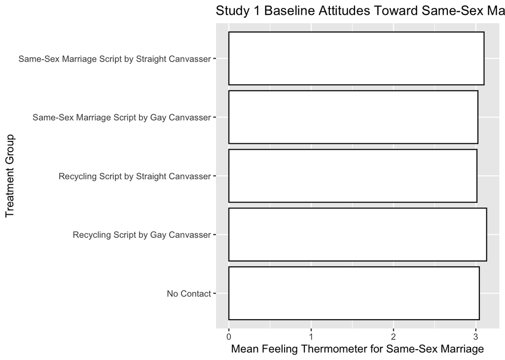

```r
ggplot(summarize(group_by(gaystudy1wave1, treatment), mean_ssm = mean(ssm)), aes(x = mean_ssm, y = treatment)) +
  geom_col(stat = "identity", color = "black", fill = "white") +
  labs(title = "Study 1 Baseline Attitudes Toward Same-Sex Marriage",
       x = "Mean Feeling Thermometer for Same-Sex Marriage",
       y = "Treatment Group")
```

## 1.2 Checking Balance and Comparing Outcomes

### Q1.5

From Q1.2 and Q1.3, we have:

```r
gaystudy1wave1_treatmentmean <- mean(gaystudy1wave1$ssm[gaystudy1wave1$treatment == "Same-Sex Marriage Script by Gay Canvasser"])
gaystudy1wave1_treatmentsd <- sd(gaystudy1wave1$ssm[gaystudy1wave1$treatment == "Same-Sex Marriage Script by Gay Canvasser"])
gaystudy1wave1_controlmean <- mean(gaystudy1wave1$ssm[gaystudy1wave1$treatment == "No Contact"])
gaystudy1wave1_controlsd <- sd(gaystudy1wave1$ssm[gaystudy1wave1$treatment == "No Contact"])

gaystudy1wave1_treatmentmean
```

```
## [1] 3.025195
```

```r
gaystudy1wave1_treatmentsd
```

```
## [1] 1.666099
```

```r
gaystudy1wave1_controlmean
```

```
## [1] 3.042764
```

```r
gaystudy1wave1_controlsd
```

```
## [1] 1.68054
```

```r
(gaystudy1wave1_treatmentmean - gaystudy1wave1_controlmean)/sqrt(((gaystudy1wave1_treatmentsd)^2+(gaystudy1wave1_controlsd)^2)/2)
```

```
## [1] -0.01049935
```

Yes, these groups look similar at baseline. Their standardized difference, -0.01049935, is below 0.25 in absolute value.

### Q1.6

```r
gaystudy1wave2 <- gay[(gay$study == 1) & (gay$wave == 2),]
gaystudy1wave2_treatmentmean <- mean(gaystudy1wave2$ssm[gaystudy1wave2$treatment == "Same-Sex Marriage Script by Gay Canvasser"])
gaystudy1wave2_controlmean <- mean(gaystudy1wave2$ssm[gaystudy1wave2$treatment == "No Contact"])

gaystudy1wave2_treatmentmean
```

```
## [1] 3.139489
```

```r
gaystudy1wave2_controlmean
```

```
## [1] 3.039615
```

```r
gaystudy1wave2_treatmentmean-gaystudy1wave2_controlmean
```

```
## [1] 0.09987463
```

The difference in means is positive 0.09987463. Since the groups were balanced at baseline, this difference at Wave 2 suggests that the treatment has had some effect in improving the treatment group’s attitudes toward same-sex marriage compared to the control group.

# Part 2: The Forensic Discovery

## 2.1 The Baseline Distribution

### Q2.1

```r
gay_r <- read_csv("data/raw/gayreshaped.csv")
ccap <- read_csv("data/raw/ccap2012.csv")
```

```
## ──────────────────────────────────────────────────────── Delimiter: "," dbl
## (3): ...1, caseid, gaytherm
```

```r
dim(gay_r)
```

```
## [1] 11948     6
```

```r
dim(ccap)
```

```
## [1] 43998     3
```

```r
colnames(gay_r)
```

```
## [1] "study"     "treatment" "therm1"    "therm2"    "therm3"    "therm4"
```

```r
colnames(ccap)
```

```
## [1] "...1"     "caseid"   "gaytherm"
```

The dataset `gay_r` has 11948 observations for 6 columns `study`, `treatment`, `therm1`, `therm2`, `therm3`, and `therm4`.

The dataset `ccap` has 43998 observations for 3 columns `caseid`, `gaytherm`, and a blank column for the observation number.

### Q2.2

```r
study1_therm1 <- c(gay_r[gay_r$study == 1,]$therm1)

mean(study1_therm1)
```

```
## [1] 58.37625
```

```r
median(study1_therm1)
```

```
## [1] 52
```

```r
sd(study1_therm1)
```

```
## [1] 28.50288
```

```r
ccap_gaytherm <- c(ccap$gaytherm)

mean(ccap_gaytherm, na.rm = TRUE)
```

```
## [1] 58.70517
```

```r
median(ccap_gaytherm, na.rm = TRUE)
```

```
## [1] 54
```

```r
sd(ccap_gaytherm, na.rm = TRUE)
```

```
## [1] 29.36892
```

For `gay_r` and `ccap`, respectively, the feeling thermometer statistics are:

Means: 58.37625, 58.70517

Medians: 52, 54

Standard deviations: 28.50288, 29.36892

All 3 statistics are strikingly similar. The means differ by less than 0.4, the medians differ by 2, and the standard deviations differ by less than 1. This level of similarity suggests that there might be some overlap in the data itself.

### Q2.3

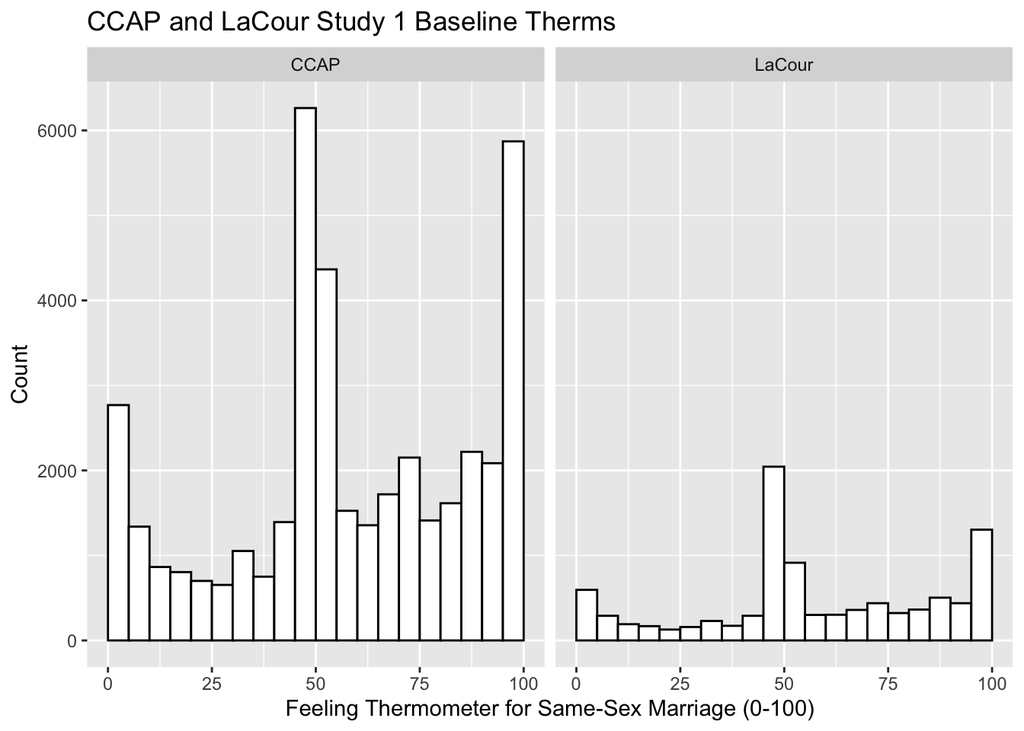

```r
study1_baselinetherm <- gay_r[gay_r$study == 1,] %>%
  rename(therm = therm1) %>%
  mutate(source = "LaCour")

ccap_therm <- ccap %>%
  rename(therm = gaytherm) %>%
  mutate(source = "CCAP")

lacour_ccap <- bind_rows(study1_baselinetherm, ccap_therm)

ggplot(lacour_ccap, aes(x = therm)) +
  geom_histogram(breaks = seq(0, 100, by = 5), color = "black", fill = "white") +
  facet_wrap(~source) +
  labs(title = "CCAP and LaCour Study 1 Baseline Therms",
       x = "Feeling Thermometer for Same-Sex Marriage (0-100)",
       y = "Count")
```

The two datasets do not appear to have come from different populations. The shape of the distribution is almost exactly mirrored in LaCour’s data, with the main difference being the sample size. There are noticeable peaks at 0, 50, and 100 in both datasets, which is to be expected due to heaping, but the distribution in between those values is also highly similar in terms of shape and relative proportions.

## 2.2 Re-test Reliability

### Q2.4

```r
study1_control <- gay_r[(gay_r$treatment == "No Contact") & (gay_r$study == 1),]
cor(study1_control$therm1, study1_control$therm2, use = "complete.obs")
```

```
## [1] 0.9975817
```

```r
sd(study1_control$therm2 - study1_control$therm1, na.rm = TRUE)
```

```
## [1] 1.987678
```

```r
study2_control <- gay_r[(gay_r$treatment == "No Contact") & (gay_r$study == 2),]
cor(study2_control$therm1, study2_control$therm2, use = "complete.obs")
```

```
## [1] 0.9734449
```

```r
sd(study2_control$therm2 - study2_control$therm1, na.rm = TRUE)
```

```
## [1] 6.605738
```

Study 2 shows a more plausible pattern with a correlation of 0.9734449 in the re-test data and a standard deviation of 6.605738, matching a reasonable re-test correlation in the range of 0.95-0.97 and substantial variability. On the other hand, Study 1 has a suspiciously high correlation of 0.9975817 and a low standard deviation of 1.987678, making it unlikely to have drawn from data with real people who change their minds. Thus, Study 2 more accurately reflects real-world changes in individuals’ feelings between re-testing.

### Q2.5

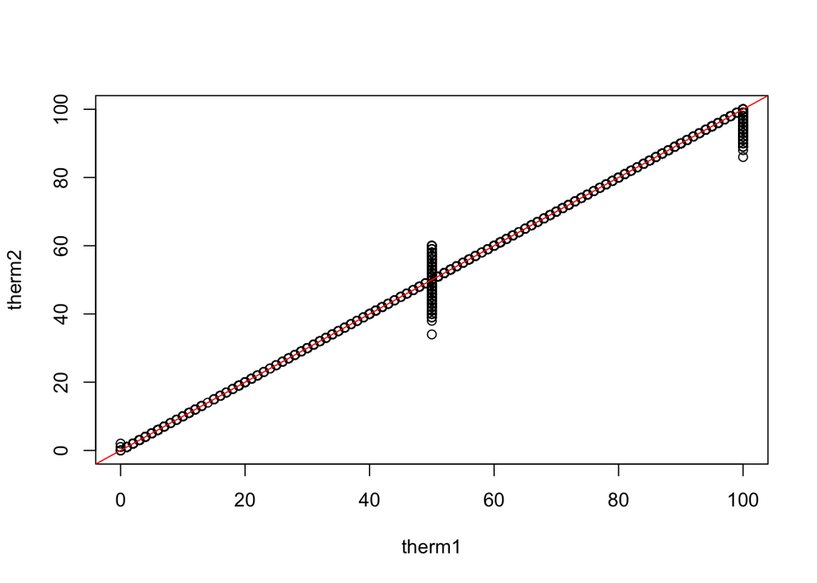

```r
plot(therm2 ~ therm1, data = study1_control)
abline(a = 0, b = 1, col = "red")
```

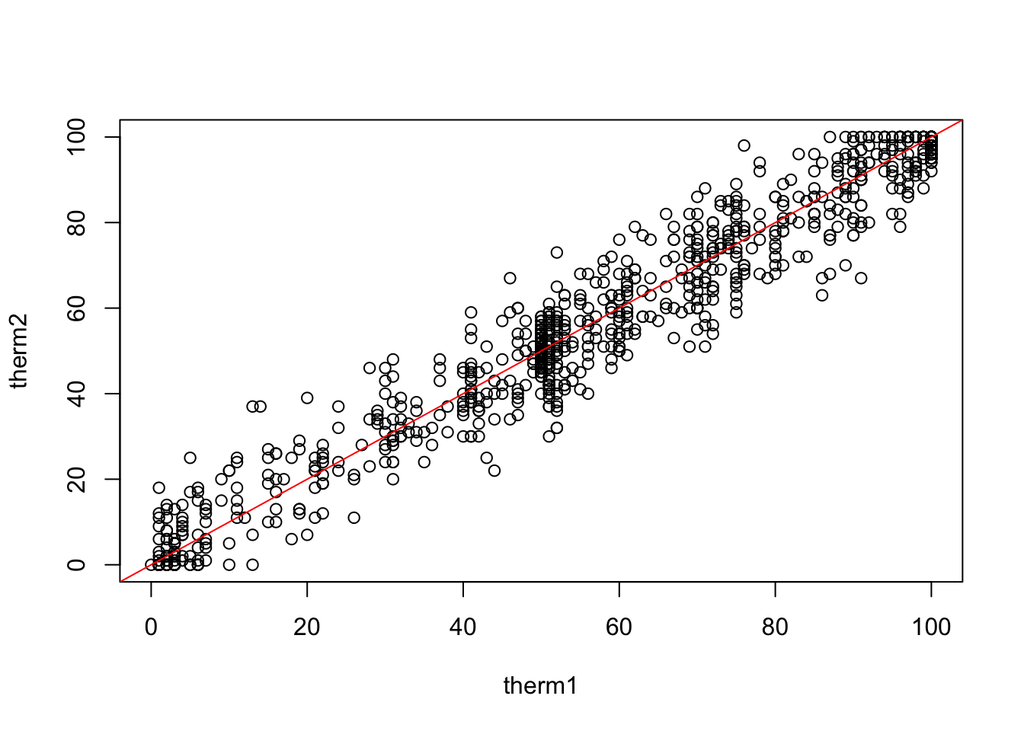

```r
plot(therm2 ~ therm1, data = study2_control)
abline(a = 0, b = 1, col = "red")
```

## 2.3 Putting It All Together

### Q2.6

# 3 Part 3: What Real Data Looks Like

## 3.1 Comparing Baselines

### Q3.1

```r
study2 = gay_r[gay_r$study == 2,]
dim(study2)
```

```
## [1] 2441    6
```

```r
dim(study2[study2$treatment == "No Contact",])
```

```
## [1] 1203    6
```

```r
dim(study2[study2$treatment == "Same-Sex Marriage Script by Gay Canvasser",])
```

```
## [1] 1238    6
```

```r
mean(study2[study2$treatment == "No Contact",]$therm1)
```

```
## [1] 57.88612
```

```r
sd(study2[study2$treatment == "No Contact",]$therm1)
```

```
## [1] 28.69655
```

```r
mean(study2[study2$treatment == "Same-Sex Marriage Script by Gay Canvasser",]$therm1)
```

```
## [1] 59.35057
```

```r
sd(study2[study2$treatment == "Same-Sex Marriage Script by Gay Canvasser",]$therm1)
```

```
## [1] 28.41578
```

Study 2 contains 2441 observations, with 1203 from the control group and 1238 from the treatment group. The mean and SD of `therm1` for the control group are 57.88612 and 28.69655, respectively. The mean and SD of `therm1` for the treatment group are 59.35057 and 28.41578, respectively.

### Q3.2

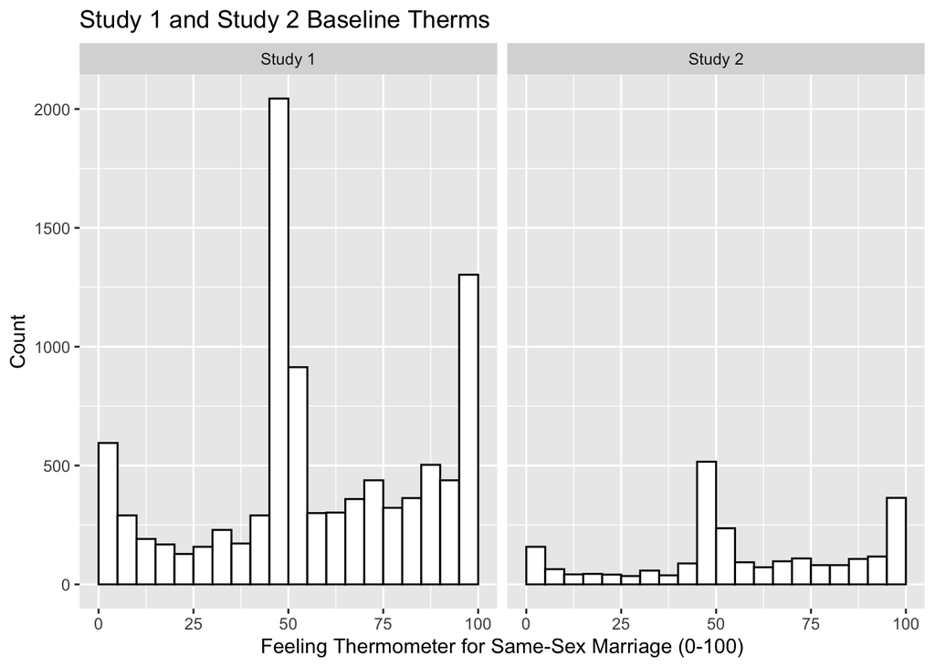

```r
study1_baselinetherm <- gay_r[gay_r$study == 1,] %>%
  rename(therm = therm1) %>%
  mutate(source = "Study 1")
study2_baselinetherm <- gay_r[gay_r$study == 2,] %>%
  rename(therm = therm1) %>%
  mutate(source = "Study 2")

study1_study2 <- bind_rows(study1_baselinetherm, study2_baselinetherm)

ggplot(study1_study2, aes(x = therm)) +
  geom_histogram(breaks = seq(0, 100, by = 5), color = "black", fill = "white") +
  facet_wrap(~source) +
  labs(title = "Study 1 and Study 2 Baseline Therms",
       x = "Feeling Thermometer for Same-Sex Marriage (0-100)",
       y = "Count")
```

The two datasets still appear to have come from similar populations, since the shapes of the distributions are still extremely similar. As before, both datasets still have modes around 50, 0, and 100.

## 3.2 Checking Balance and Comparing Outcomes in Study 2

### Q3.3

From Q3.1, we have:

```r
controlbaseline_mean <- mean(study2[study2$treatment == "No Contact",]$therm1)
controlbaseline_sd <- sd(study2[study2$treatment == "No Contact",]$therm1)
treatmentbaseline_mean <- mean(study2[study2$treatment == "Same-Sex Marriage Script by Gay Canvasser",]$therm1)
treatmentbaseline_sd <- sd(study2[study2$treatment == "Same-Sex Marriage Script by Gay Canvasser",]$therm1)

controlbaseline_mean
```

```
## [1] 57.88612
```

```r
controlbaseline_sd
```

```
## [1] 28.69655
```

```r
treatmentbaseline_mean
```

```
## [1] 59.35057
```

```r
treatmentbaseline_sd
```

```
## [1] 28.41578
```

```r
(treatmentbaseline_mean - controlbaseline_mean)/sqrt(((treatmentbaseline_sd)^2+(controlbaseline_sd)^2)/2)
```

```
## [1] 0.05128243
```

Yes, these groups look similar at baseline. Their standardized difference, 0.05128243, is below 0.25 in absolute value.

### Q3.4

```r
controlpost_mean <- mean(study2[study2$treatment == "No Contact",]$therm2, na.rm = TRUE)
treatmentpost_mean <- mean(study2[study2$treatment == "Same-Sex Marriage Script by Gay Canvasser",]$therm2, na.rm = TRUE)

controlpost_mean
```

```
## [1] 57.63523
```

```r
treatmentpost_mean
```

```
## [1] 61.20311
```

```r
treatmentpost_mean - controlpost_mean
```

```
## [1] 3.567885
```

The difference in means is positive 3.567885. Since the groups were balanced at baseline, this difference suggests that the treatment has had an effect in improving the treatment group’s attitudes toward same-sex marriage compared to the control group.

## 3.3 Uncertainty Around the Difference

### Q3.5

```r
controlpost_sd <- sd(study2[study2$treatment == "No Contact",]$therm2, na.rm = TRUE)
treatmentpost_sd <- sd(study2[study2$treatment == "Same-Sex Marriage Script by Gay Canvasser",]$therm2, na.rm = TRUE)

controlpost_obs <- length(study2[study2$treatment == "No Contact",]$therm2) - sum(is.na(study2[study2$treatment == "No Contact",]$therm2))
treatmentpost_obs <- length(study2[study2$treatment == "Same-Sex Marriage Script by Gay Canvasser",]$therm2) - sum(is.na(study2[study2$treatment == "Same-Sex Marriage Script by Gay Canvasser",]$therm2))

SEpost <- sqrt((treatmentpost_sd)^2/treatmentpost_obs + (controlpost_sd)^2/controlpost_obs)

SEpost
```

```
## [1] 1.242138
```

```r
(treatmentpost_mean - controlpost_mean) - 1.96*SEpost
```

```
## [1] 1.133294
```

```r
(treatmentpost_mean - controlpost_mean) + 1.96*SEpost
```

```
## [1] 6.002475
```

The standard error is 1.242138, and the 95% confidence interval is (1.133294, 6.002475). The confidence interval does not include 0, which suggests that we can reject the null hypothesis and conclude there is a statistically significant positive difference between the treatment group and control group post-conversation.

## 3.4 Tracking Attitudes Over Time

### Q3.6

```r
cor(study2[study2$treatment == "No Contact",]$therm1, study2[study2$treatment == "No Contact",]$therm2, use = "complete.obs")
```

```
## [1] 0.9734449
```

```r
cor(study2[study2$treatment == "No Contact",]$therm1, study2[study2$treatment == "No Contact",]$therm3, use = "complete.obs")
```

```
## [1] 0.9594085
```

```r
cor(study2[study2$treatment == "No Contact",]$therm1, study2[study2$treatment == "No Contact",]$therm4, use = "complete.obs")
```

```
## [1] 0.9709017
```

The correlations do not necessarily steadily decay over time but do fluctuate within/around the reasonable range of 0.95-0.97, suggesting that real survey display variation from shifts in feeling thermometers between measurements and are not completely stable.

### Q3.7

Although both studies had similar baseline distributions, Study 2 has lower correlations between waves, with a maximum between-thermometer correlation of 0.9734449 compared to the between-thermometer correlation of 0.9975817 for Study 1, suggesting that Study 2 more accurately captures the variation and instability in real survey measurements.

# Part 4: Formalizing the Evidence with Regression

## 4.1 Regression as a Fraud Detector

### Q4.1

```r
fit_s1 <- lm(therm2 ~ therm1, data = gay_r[(gay_r$study == 1) & (gay_r$treatment == "No Contact"),])
summary(fit_s1)
```

```
##
## Call:
## lm(formula = therm2 ~ therm1, data = gay_r[(gay_r$study == 1) &
##     (gay_r$treatment == "No Contact"), ])
##
## Residuals:
##      Min       1Q   Median       3Q      Max
## -15.8631  -0.1121   0.1746   0.4312  10.1369
##
## Coefficients:
##             Estimate Std. Error t value Pr(>|t|)
## (Intercept) 0.240430   0.066000   3.643 0.000273 ***
## therm1      0.992454   0.001012 980.624  < 2e-16 ***
## ---
## Signif. codes:  0 '***' 0.001 '**' 0.01 '*' 0.05 '.' 0.1 ' ' 1
##
## Residual standard error: 1.976 on 4668 degrees of freedom
##   (568 observations deleted due to missingness)
## Multiple R-squared:  0.9952, Adjusted R-squared:  0.9952
## F-statistic: 9.616e+05 on 1 and 4668 DF,  p-value: < 2.2e-16
```

The slope, $\hat{\beta}_1$, is 0.992454, which indicates that every increase of 1 in `therm1` is associated with an increase of 0.992454 in `therm2`. The R-squared is 0.9952, which indicates that the model explains 99.52% of the variability of `therm2`. The residual standard error is 1.976.

### Q4.2

```r
fit_s2 <- lm(therm2 ~ therm1, data = study2[study2$treatment == "No Contact",])
summary(fit_s2)
```

```
##
## Call:
## lm(formula = therm2 ~ therm1, data = study2[study2$treatment ==
##     "No Contact", ])
##
## Residuals:
##      Min       1Q   Median       3Q      Max
## -22.7102  -3.4793   0.0363   3.5092  22.8455
##
## Coefficients:
##             Estimate Std. Error t value Pr(>|t|)
## (Intercept) 1.561897   0.457098   3.417 0.000658 ***
## therm1      0.968662   0.007074 136.935  < 2e-16 ***
## ---
## Signif. codes:  0 '***' 0.001 '**' 0.01 '*' 0.05 '.' 0.1 ' ' 1
##
## Residual standard error: 6.547 on 1037 degrees of freedom
##   (164 observations deleted due to missingness)
## Multiple R-squared:  0.9476, Adjusted R-squared:  0.9475
## F-statistic: 1.875e+04 on 1 and 1037 DF,  p-value: < 2.2e-16
```

The slope, $\hat{\beta}_1$, is 0.968662, which indicates that every increase of 1 in `therm1` is associated with an increase of 0.968662 in `therm2`. The R-squared is 0.9476, which indicates that the model explains 94.76% of the variability of `therm2`. The residual standard error is 6.547.

## 4.2 Comparing Groups with Regression

### Q4.3

```r
study2_treatmentcontrol <- study2[study2$treatment == "Same-Sex Marriage Script by Gay Canvasser" | study2$treatment == "No Contact",]

treated <- ifelse(study2_treatmentcontrol$treatment == "Same-Sex Marriage Script by Gay Canvasser", 1, 0)

study2_treatmentcontrol <- mutate(study2_treatmentcontrol, treated = treated)

fit_treated <- lm(therm2 ~ treated, data = study2_treatmentcontrol)
summary(fit_treated)
```

```
##
## Call:
## lm(formula = therm2 ~ treated, data = study2_treatmentcontrol)
##
## Residuals:
##     Min      1Q  Median      3Q     Max
## -61.203 -15.635  -3.203  24.365  42.365
##
## Coefficients:
##             Estimate Std. Error t value Pr(>|t|)
## (Intercept)  57.6352     0.8895  64.794  < 2e-16 ***
## treated       3.5679     1.2423   2.872  0.00412 **
## ---
## Signif. codes:  0 '***' 0.001 '**' 0.01 '*' 0.05 '.' 0.1 ' ' 1
##
## Residual standard error: 28.67 on 2130 degrees of freedom
##   (309 observations deleted due to missingness)
## Multiple R-squared:  0.003857,   Adjusted R-squared:  0.00339
## F-statistic: 8.248 on 1 and 2130 DF,  p-value: 0.00412
```

The slope, $\hat{\beta}_1$, is 3.5679, which indicates that the mean `therm2` of the treatment group is 3.5679 higher than the mean `therm2` of the control group. This value matches the calculated difference in means of 3.567885 from Q3.4. The standard error, t-statistic, and p-value for $\hat{\beta}_1$ are 1.2423, 2.872, and 0.00412, respectively, so the difference between the two groups, is statistically significant at the $\alpha=0.05$ level since $p<0.05$. $\hat{\beta}_0$ estimates the mean `therm2` of the control group, or 57.6352, which also matches the calculated control group mean of 57.63523 from Q3.4.

## 4.3 Controlling for Baseline Attitudes

### Q4.4

```r
fit_treatedtherm1 <- lm(therm2 ~ treated + therm1, data = study2_treatmentcontrol)
summary(fit_treatedtherm1)
```

```
##
## Call:
## lm(formula = therm2 ~ treated + therm1, data = study2_treatmentcontrol)
##
## Residuals:
##     Min      1Q  Median      3Q     Max
## -27.194  -4.476  -0.476   3.688  35.558
##
## Coefficients:
##             Estimate Std. Error t value Pr(>|t|)
## (Intercept) 1.727135   0.423275    4.08 4.66e-05 ***
## treated     2.458857   0.341052    7.21 7.76e-13 ***
## therm1      0.965808   0.005973  161.69  < 2e-16 ***
## ---
## Signif. codes:  0 '***' 0.001 '**' 0.01 '*' 0.05 '.' 0.1 ' ' 1
##
## Residual standard error: 7.87 on 2129 degrees of freedom
##   (309 observations deleted due to missingness)
## Multiple R-squared:  0.925,  Adjusted R-squared:  0.9249
## F-statistic: 1.313e+04 on 2 and 2129 DF,  p-value: < 2.2e-16
```

### Q4.5

The R-squared value increases from 0.003857 to 0.925. Adding `therm1` creates this dramatic increase in R-squared because it explains a large portion of the variability in `therm2`, which indicates that the vast majority of the variation in follow-up attitudes is better explained by where people started compared to the treatment itself.

```r
personA <- data.frame(treated = 1, therm1 = 50)
personB <- data.frame(treated = 0, therm1 = 50)
predict(fit_treatedtherm1, personA)
```

```
##        1
## 52.47638
```

```r
predict(fit_treatedtherm1, personB)
```

```
##        1
## 50.01752
```

```r
predict(fit_treatedtherm1, personA) - predict(fit_treatedtherm1, personB)
```

```
##        1
## 2.458857
```

The predicted difference in Wave 2 attitudes is 2.458857, consistent with the slope coefficient of the model.